# HW3

Ali Furkan Yavuz

11/19/2018

# Classification Using NN Algorithms and Logistic Regression

In the homework two(2) different NN algorithms and Logistic Regression used to make predictions on classes.

## Task1.a Visialisation of insatances

The homework will require using specific packages so these packages recalled first.

```r
library(data.table)
library(plotly)
library(FNN)
library(caret)
library(kknn)
library(penalized)
```

To start the analysis, the data is read using relevant functions and data tables are created.

```r
X_Train=data.table(read.table("/Users/alifurkanyavuz/Desktop/IE582/HWs/HW 3/X_TRAIN.dms"))
Y_Train=data.table(read.table("/Users/alifurkanyavuz/Desktop/IE582/HWs/HW 3/Y_TRAIN.dms"))
Z_Train=data.table(read.table("/Users/alifurkanyavuz/Desktop/IE582/HWs/HW 3/X_TRAIN.dms"))
X_Test=data.table(read.table("/Users/alifurkanyavuz/Desktop/IE582/HWs/HW 3/X_TEST.dms"))
Y_Test=data.table(read.table("/Users/alifurkanyavuz/Desktop/IE582/HWs/HW 3/Y_TEST.dms"))
Z_Test=data.table(read.table("/Users/alifurkanyavuz/Desktop/IE582/HWs/HW 3/X_TEST.dms"))
```

The data is arranged with the following code, the same approach used for other instances also. The code for Instance1 is provided, the other will not be provided.

This code is for data pre-processsing, it takes the information needed for the instance choosed and then merge the data to plot later.

```r
Col_Num=11

Instance_1_X=X_Train[Col_Num]
Instance_1_X=Instance_1_X[,V1:=NULL]
Instance_1_X=t(Instance_1_X)
Instance_1_X=as.data.frame(Instance_1_X)


Instance_1_Y=Y_Train[Col_Num]
Instance_1_Y=Instance_1_Y[,V1:=NULL]
Instance_1_Y=t(Instance_1_Y)
Instance_1_Y=as.data.frame(Instance_1_Y)
colnames(Instance_1_Y)[1]="V2"

Instance_1_Z=Z_Train[Col_Num]
Instance_1_Z=Instance_1_Z[,V1:=NULL]
Instance_1_Z=t(Instance_1_Z)
Instance_1_Z=as.data.frame(Instance_1_Z)
colnames(Instance_1_Z)[1]="V3"

Instance_1=cbind(Instance_1_X,Instance_1_Y,Instance_1_Z)
```

The graphs are created using plot_ly and the result is a 3-d graph

```r
p_1 <- plot_ly(Instance_1, x = ~V1, y = ~V2, z = ~V3,type = "scatter3d",mode=('markers'))
```

Graphs for the instances provided as follows.

### Instance 1

[interactive chart not shown]

### Instance 2

[interactive chart not shown]

### Instance 3

[interactive chart not shown]

### Instance 4

[interactive chart not shown]

### Instance 5

[interactive chart not shown]

### Instance 6

[interactive chart not shown]

### Instance 7

[interactive chart not shown]

### Instance 8

[interactive chart not shown]

As you can see from the plots in the first imrpression it looks like there is no rlation between patterns proviced and the graphs.

But if you go further and look the characteristics of the plots in detail you will see the relation.

For example, In the first graph you should expect to see a pattern increase and then decrease. If you play with the graph you can recognize the patterns match.

The same logic is true for others too.

## Task1.b Applying NN methods

First data need to arranged to use in the models. The following code prepares data for the analysis.

```r
colnames(X_Train)=as.character(c(1:316))
colnames(Y_Train)=as.character(c(317:632))
colnames(Z_Train)=as.character(c(633:948))
combined_data=cbind(X_Train,Y_Train,Z_Train)
combined_data[,c("317","633"):=NULL]
combined_for_kknn=combined_data
colnames(combined_for_kknn)[1]="class"

classes_combined=combined_data[,"1"]

classes_combined=as.vector(classes_combined)

classes_combined=as.numeric(unlist(classes_combined))

combined_data[,"1":=NULL]
```

Then we need to decide which distance measures will be used. I choosed Manhattan and Euclidean.

Caret package’s train function used for both case but different functions called knn() and kknn() used to test the data.

I also used Sys.time() function to record the evaluation times.

Following code used to train knn using euclidean

```r
start_time_euc=Sys.time()
knn_euc=train(combined_data,classes_combined,method = "knn", preProcess = c("center", "scale"),
      tuneLength = 20,trControl = trainControl(method = "cv",number = 10) )
end_time_euc=Sys.time()
run_time_euc=end_time_euc-start_time_euc
```

Following code train a knn using manhattan distance.

```r
start_time_euc=Sys.time()
knn_man=train(combined_data,classes_combined,method = "kknn", preProcess = c("center", "scale"),
              tuneLength = 20,tuneGrid = expand.grid(kmax=c(1:20),distance=1,kernel="optimal"),trControl = trainControl(method = "cv", number = 10) )
end_time_euc=Sys.time()
run_time_man=end_time_euc-start_time_euc
```

## Task1.c Testing the models on Test data

First data need to arranged to use in the models. The following code prepares data for the analysis.

```r
colnames(X_Test)=as.character(c(1:316))
colnames(Y_Test)=as.character(c(317:632))
colnames(Z_Test)=as.character(c(633:948))
combined_data_test=cbind(X_Test,Y_Test,Z_Test)
combined_data_test[,c("317","633"):=NULL]

combined_for_kknn_test=combined_data_test
colnames(combined_for_kknn_test)[1]="class"

classes_combined_test=combined_data_test[,"1"]
classes_combined_test=as.vector(classes_combined_test)
classes_combined_test=as.numeric(unlist(classes_combined_test))

combined_data_test[,"1":=NULL]
```

Classification performed on test data using knn() fuction-Euclidean

K values determined on the previous code using train()

```r
predict_knn_euc=knn(combined_data,combined_data_test,classes_combined,k=5)
```

Classification performed on test data using kknn() fuction-Manhattan

K values determined on the previous code using train()

```r
predict_knn_man=kknn(formula = class~. ,combined_for_kknn,combined_data_test,k=4,distance = 1)
```

Confusion Matrix for the model which use euclidean distance created

```r
cm_knn_euc=table(Predictions=as.numeric(as.character(predict_knn_euc)), Real=classes_combined_test)

predict_knn_man$fitted.values
knn_man_confusion=predict_knn_man$CL
knn_man_confusion=as.data.table(knn_man_confusion)
knn_man_confusion=knn_man_confusion[,V4]
```

Confusion Matrix for the model which use manhattan distance created

```r
cm_knn_man=table(Prediction=knn_man_confusion, Real=classes_combined_test)
```

Confusion Matrix for the Model which use euclidean distance is as follows

```r
cm_knn_euc
```

```
##            Real
## Predictions   1   2   3   4   5   6   7   8
##           1 426   3   0   4   6  38  43   2
##           2   0 448   0   0   0   3   0   0
##           3   0   0 435   0  18  83  15   2
##           4   1   0   0 418 104  34   0   3
##           5   0   0  17  26 297  36   1   5
##           6   6   0   0   2   3 244   1   1
##           7   0   1   1   0   0   5 386   0
##           8   4   0   1   0   5   6   1 447
```

Confusion Matrix for the Model which use manhattan distance is as follows

```r
cm_knn_man
```

```
##           Real
## Prediction   1   2   3   4   5   6   7   8
##          1 409   3   0   6   6  43  50   4
##          2   0 445   0   0   0   2   0   0
##          3   0   0 413   0  31  78  16   4
##          4   3   0   0 366 106  34   0   7
##          5   2   0  25  65 273  36   2   4
##          6  12   0  11   7  10 241   4   4
##          7   8   4   4   1   1   7 371   1
##          8   3   0   1   5   6   8   4 436
```

Runtime for the Model which use euclidean distance is as follows

```r
run_time_euc
```

```
## Time difference of 3.183999 mins
```

Runtime for the Model which use manhattan distance is as follows

```r
run_time_man
```

```
## Time difference of 51.03251 mins
```

## Task2.a Testing the models on Test data

To start the analysis, the data is read using relevant functions and data tables are created.

```r
setwd('/Users/alifurkanyavuz/Desktop/NN_Classification')
fname='ecgTRAIN' # data path
gname='ecgTEST'
traindata <- as.matrix(read.table(fname))  # read data into a matrix named traindata
testdata <- as.matrix(read.table(gname))  # read data into a matrix named testdata
```

Data need to be arranged to use in the models. The following code prepares data for the analysis.

```r
trainclass=traindata[,1] # takes -1 and 1
trainclass[trainclass==-1]=0

testclass=testdata[,1]
testclass[testclass==-1]=0

#drop first column
traindata=traindata[,2:ncol(traindata)]
testdata=testdata[,2:ncol(testdata)]
```

I need to find the optimal data to use in the penalized approach, the following code used to find the optimal Lambda value

```r
trainclass=as.numeric(trainclass)

lr_ecg=optL1(response=trainclass, penalized= traindata,fusedl=TRUE,model="logistic", fold=10,standardize=TRUE)

lr_ecg$lambda
```

Then the following funvtion used to fit a model using the lambda found.

```r
# fit a logistic regression model based on found lambda

fit_lr_ecg=penalized(response = trainclass, penalized = traindata, lambda1= lr_ecg$lambda,
                     fusedl = TRUE, model = "logistic",standardize=TRUE)
fit_lr_ecg
```

Then the outcomes are predicted using the model built and confusion matrix is created

```r
#Predict the outcome based on model
testdata_frame=as.data.frame(testdata)

predict_ecg=predict(fit_lr_ecg,penalized=testdata, data=testdata_frame)
predict_ecg
vec_pred=predict_ecg
vec_pred[vec_pred>=0.5]=1
vec_pred[vec_pred<0.5]=0
cm_lr_ecg=table(Predictions=vec_pred, Real=testclass)
cm_lr_ecg
```

The accuracy for the model is 82% based on the confusion matrix

```r
cm_lr_ecg
```

```
##            Real
## Predictions  0  1
##           0 25  7
##           1 11 57
```

## Task2.b Interpretations of Coefficients of the model

Coefficients of the model as follows. As can be seen some of the values are big some of them are small.

This means if the value is big this variable is important to predict the class. But if it is small, it is means it is less important to predict the class.

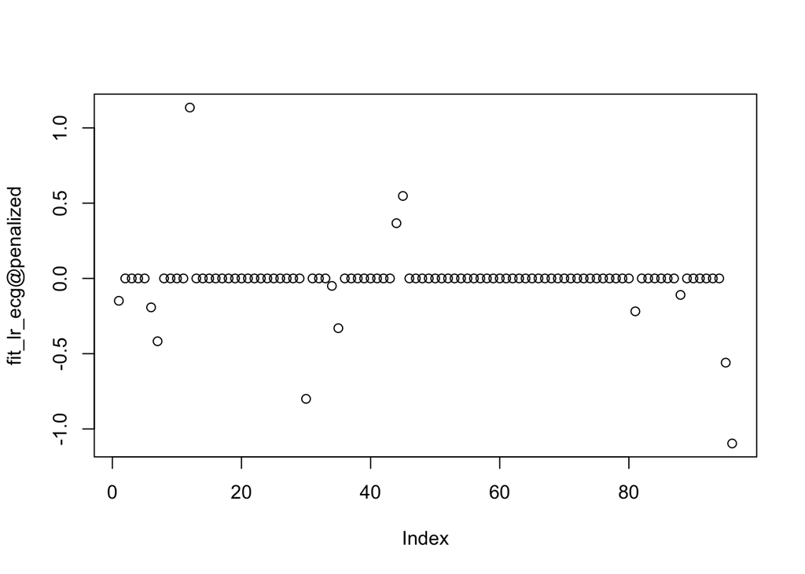

```r
plot(fit_lr_ecg@penalized)
```

## Task2.c Classification Using the Transformed data Data is transformed using the following formula. 𝑦𝑡 = 𝑥𝑡 − 𝑥𝑡−1 for 𝑡 = 2,3, … , 𝑇

Calculation of the transformed data is done using the following code.

```r
#matrix operation Train Data
nrow=nrow(traindata)
ncol=ncol(traindata)
old_matrix=as.matrix(traindata)
ECG_train_new = as.matrix(traindata)
for(r in 1:nrow) {
  for(c in 2:ncol){
    ECG_train_new[r,c-1] = old_matrix[r,c]-old_matrix[r,c-1]
  }
}
ncol(ECG_train_new)
ECG_train_new
ECG_train_new=ECG_train_new[,1:95]
ECG_train_new

#matrix operation Test Data
nrow=nrow(testdata)
ncol=ncol(testdata)
old_matrix=as.matrix(testdata)
ECG_test_new = as.matrix(testdata)
for(r in 1:nrow) {
  for(c in 2:ncol){
    ECG_test_new[r,c-1] = old_matrix[r,c]-old_matrix[r,c-1]
  }
}
ncol(ECG_test_new)
ECG_test_new
ECG_test_new=ECG_test_new[,1:95]
ECG_test_new
```

Same process above used to train logistic regresssion and predict outcomes. Confusion marix is created afterwards.

```r
#Find Lambda Value logistic regression


lr_ecg_timeseries=optL1(response=trainclass, penalized= ECG_train_new,fusedl=TRUE,model="logistic",
             fold=10,standardize=TRUE)


# fit a logistic regression model based on found lamcda

fit_lr_ecg_timeseries=penalized(response = trainclass, penalized = ECG_train_new, lambda1= lr_ecg_timeseries$lambda,
                     fusedl = TRUE, model = "logistic",standardize=TRUE)

#Predict the outcome based on lambda
testdata_frame_timeseries=as.data.frame(ECG_test_new)

predict_ecg_timeseries=predict(fit_lr_ecg_timeseries,penalized=ECG_test_new, data=testdata_frame_timeseries)

vec_pred_timeseries=predict_ecg_timeseries
vec_pred_timeseries[vec_pred_timeseries>=0.5]=1
vec_pred_timeseries[vec_pred_timeseries<0.5]=0
cm_lr_ecg_timeseries=table(Predictions=vec_pred_timeseries, Real=testclass)
cm_lr_ecg_timeseries
```

The accuracy for the model is 80% based on the confusion matrix

```r
cm_lr_ecg_timeseries
```

```
##            Real
## Predictions  0  1
##           0 26 10
##           1 10 54
```

## Task2.d Interpretations of Coefficients of the model

Coefficients of the model as follows. As can be seen some of the values are big some of them are small.

This means if the value is big this variable is important to predict the class. But if it is small, it is means it is less important to predict the class.

But compared the coeeficients if the previous model, the coeeficients are distributed randomly compared to first model.

It can said that trend is removed using this approach.

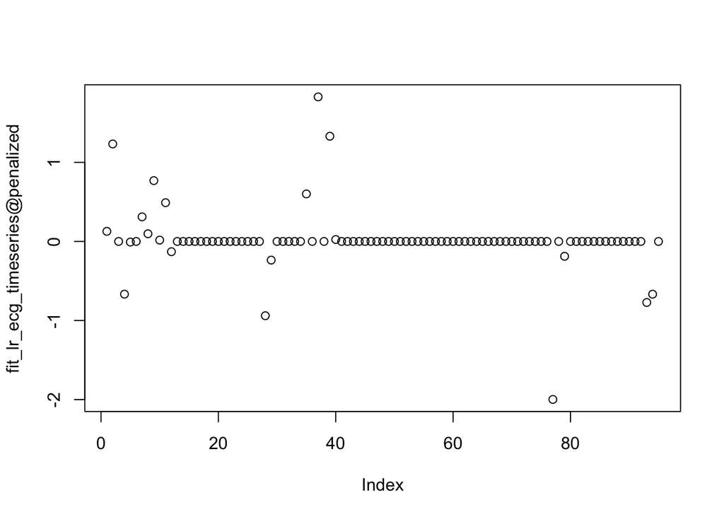

```r
plot(fit_lr_ecg_timeseries@penalized)
```